### Exercise quality prediction

#### Overview

This document details the creation, training and selection of a machine learning algorithm to classify the quality of exercise (weight lifting) using accelerometer data.

Produced as part of the Coursera Practical Machine learning course, week 4 assignment.

Data, methodology and the original paper can be found at the link below, courtesy of;  
Ugulino, W.; Cardador, D.; Vega, K.; Velloso, E.; Milidiu, R.; Fuks, H.  
[Wearable Computing: Accelerometers’ Data Classification of Body Postures and Movements](http://web.archive.org/web/20161224072740/http:/groupware.les.inf.puc-rio.br/work.jsf?p1=10335)

#### Model creation and training

Training data is partitioned into a training and validation set to allow the estimation of out of sample error.

A random forest model is trained using 3 fold cross validation.

```
## Random Forest
##
## 13737 samples
##    53 predictor
##     5 classes: 'A', 'B', 'C', 'D', 'E'
##
## No pre-processing
## Resampling: Cross-Validated (3 fold)
## Summary of sample sizes: 9157, 9158, 9159
## Resampling results across tuning parameters:
##
##   mtry  Accuracy   Kappa
##    2    0.9913372  0.9890402
##   27    0.9959961  0.9949353
##   53    0.9935937  0.9918960
##
## Accuracy was used to select the optimal model using the largest value.
## The final value used for the model was mtry = 27.
```

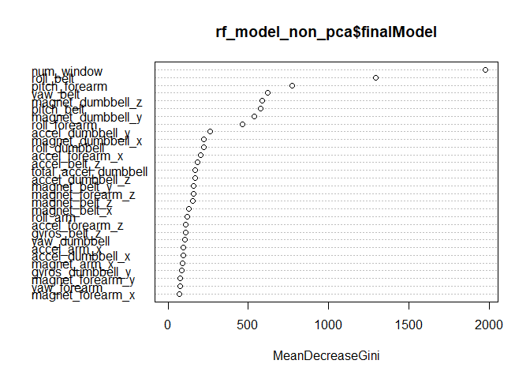

An out of sample accuracy estimate is provided by applying this model to the validation data set.

```
## Confusion Matrix and Statistics
##
##           Reference
## Prediction    A    B    C    D    E
##          A 1673    5    0    0    0
##          B    0 1134    3    0    0
##          C    0    0 1022    4    0
##          D    0    0    1  960    2
##          E    1    0    0    0 1080
##
## Overall Statistics
##
##                Accuracy : 0.9973
##                  95% CI : (0.9956, 0.9984)
##     No Information Rate : 0.2845
##     P-Value [Acc > NIR] : < 2.2e-16
##
##                   Kappa : 0.9966
##  Mcnemar's Test P-Value : NA
##
## Statistics by Class:
##
##                      Class: A Class: B Class: C Class: D Class: E
## Sensitivity            0.9994   0.9956   0.9961   0.9959   0.9982
## Specificity            0.9988   0.9994   0.9992   0.9994   0.9998
## Pos Pred Value         0.9970   0.9974   0.9961   0.9969   0.9991
## Neg Pred Value         0.9998   0.9989   0.9992   0.9992   0.9996
## Prevalence             0.2845   0.1935   0.1743   0.1638   0.1839
## Detection Rate         0.2843   0.1927   0.1737   0.1631   0.1835
## Detection Prevalence   0.2851   0.1932   0.1743   0.1636   0.1837
## Balanced Accuracy      0.9991   0.9975   0.9976   0.9976   0.9990
```

[output not shown]

Since accuracy looks acceptable a similar model will be trained using the entire training dataset and used to predict on the assigned testing data.

```r
# Train the final model
#final_model <- train(classe ~.,data=training,method="rf",trControl=fitControl,prox=TRUE)

load("final_model.rda")

# Predict the testing values
predict(final_model,newdata=testing)
```

```
##  [1] B A B A A E D B A A B C B A E E A B B B
## Levels: A B C D E
```